# Part I - (Loan Data from Prosper)

## by (Olorunleke Akindote-White)

## Introduction

> This data set contains 113,937 loans with 81 variables on each loan, including loan amount, borrower rate (or interest rate), current loan status, borrower income, and many others.

## Preliminary Wrangling

```python
# import all packages and set plots to be embedded inline
import numpy as np
import pandas as pd
import matplotlib.pyplot as plt
import seaborn as sb

%matplotlib inline
```

```python
#-- reading the dataframe
loans = pd.read_csv('prosperLoanData.csv')
```

```python
loans.head()
```

|  | ListingKey | ListingNumber | ListingCreationDate | CreditGrade | Term | LoanStatus | ClosedDate | BorrowerAPR | BorrowerRate | LenderYield | ... | LP_ServiceFees | LP_CollectionFees | LP_GrossPrincipalLoss | LP_NetPrincipalLoss | LP_NonPrincipalRecoverypayments | PercentFunded | Recommendations | InvestmentFromFriendsCount | InvestmentFromFriendsAmount | Investors |
| --- | --- | --- | --- | --- | --- | --- | --- | --- | --- | --- | --- | --- | --- | --- | --- | --- | --- | --- | --- | --- | --- |
| 0 | 1021339766868145413AB3B | 193129 | 2007-08-26 19:09:29.263000000 | C | 36 | Completed | 2009-08-14 00:00:00 | 0.16516 | 0.1580 | 0.1380 | ... | -133.18 | 0.0 | 0.0 | 0.0 | 0.0 | 1.0 | 0 | 0 | 0.0 | 258 |
| 1 | 10273602499503308B223C1 | 1209647 | 2014-02-27 08:28:07.900000000 | NaN | 36 | Current | NaN | 0.12016 | 0.0920 | 0.0820 | ... | 0.00 | 0.0 | 0.0 | 0.0 | 0.0 | 1.0 | 0 | 0 | 0.0 | 1 |
| 2 | 0EE9337825851032864889A | 81716 | 2007-01-05 15:00:47.090000000 | HR | 36 | Completed | 2009-12-17 00:00:00 | 0.28269 | 0.2750 | 0.2400 | ... | -24.20 | 0.0 | 0.0 | 0.0 | 0.0 | 1.0 | 0 | 0 | 0.0 | 41 |
| 3 | 0EF5356002482715299901A | 658116 | 2012-10-22 11:02:35.010000000 | NaN | 36 | Current | NaN | 0.12528 | 0.0974 | 0.0874 | ... | -108.01 | 0.0 | 0.0 | 0.0 | 0.0 | 1.0 | 0 | 0 | 0.0 | 158 |
| 4 | 0F023589499656230C5E3E2 | 909464 | 2013-09-14 18:38:39.097000000 | NaN | 36 | Current | NaN | 0.24614 | 0.2085 | 0.1985 | ... | -60.27 | 0.0 | 0.0 | 0.0 | 0.0 | 1.0 | 0 | 0 | 0.0 | 20 |

5 rows × 81 columns

```python
#-- inspecting the structure of the dataframe
loans.info()
```

```
<class 'pandas.core.frame.DataFrame'>
RangeIndex: 113937 entries, 0 to 113936
Data columns (total 81 columns):
ListingKey                             113937 non-null object
ListingNumber                          113937 non-null int64
ListingCreationDate                    113937 non-null object
CreditGrade                            28953 non-null object
Term                                   113937 non-null int64
LoanStatus                             113937 non-null object
ClosedDate                             55089 non-null object
BorrowerAPR                            113912 non-null float64
BorrowerRate                           113937 non-null float64
LenderYield                            113937 non-null float64
EstimatedEffectiveYield                84853 non-null float64
EstimatedLoss                          84853 non-null float64
EstimatedReturn                        84853 non-null float64
ProsperRating (numeric)                84853 non-null float64
ProsperRating (Alpha)                  84853 non-null object
ProsperScore                           84853 non-null float64
ListingCategory (numeric)              113937 non-null int64
BorrowerState                          108422 non-null object
Occupation                             110349 non-null object
EmploymentStatus                       111682 non-null object
EmploymentStatusDuration               106312 non-null float64
IsBorrowerHomeowner                    113937 non-null bool
CurrentlyInGroup                       113937 non-null bool
GroupKey                               13341 non-null object
DateCreditPulled                       113937 non-null object
CreditScoreRangeLower                  113346 non-null float64
CreditScoreRangeUpper                  113346 non-null float64
FirstRecordedCreditLine                113240 non-null object
CurrentCreditLines                     106333 non-null float64
OpenCreditLines                        106333 non-null float64
TotalCreditLinespast7years             113240 non-null float64
OpenRevolvingAccounts                  113937 non-null int64
OpenRevolvingMonthlyPayment            113937 non-null float64
InquiriesLast6Months                   113240 non-null float64
TotalInquiries                         112778 non-null float64
CurrentDelinquencies                   113240 non-null float64
AmountDelinquent                       106315 non-null float64
```

[output cut: 31 more lines]

```
LP_CustomerPayments                    113937 non-null float64
LP_CustomerPrincipalPayments           113937 non-null float64
LP_InterestandFees                     113937 non-null float64
LP_ServiceFees                         113937 non-null float64
LP_CollectionFees                      113937 non-null float64
LP_GrossPrincipalLoss                  113937 non-null float64
LP_NetPrincipalLoss                    113937 non-null float64
LP_NonPrincipalRecoverypayments        113937 non-null float64
PercentFunded                          113937 non-null float64
Recommendations                        113937 non-null int64
InvestmentFromFriendsCount             113937 non-null int64
InvestmentFromFriendsAmount            113937 non-null float64
Investors                              113937 non-null int64
dtypes: bool(3), float64(50), int64(11), object(17)
memory usage: 68.1+ MB
```

### What is the structure of your dataset?

> There are 113937 rows and 81 columns

### What is/are the main feature(s) of interest in your dataset?

> Loan Status

### What features in the dataset do you think will help support your investigation into your feature(s) of interest?

> - Borrower APR
> - Loan Term
> - Borrower Rate
> - Lender Yield
> - Listing Category
> - Occupation
> - Employment Status
> - Employment Status Duration
> - Available Bank Card credit
> - Income range'
> - Monthly Loan repayment

### Having identified the dependent variable and all its factors, we create a derived dataframe from the main data frame focusing on key features

```python
#-- first we list out all the columns in the dataframe
loans.columns
```

```
Index(['ListingKey', 'ListingNumber', 'ListingCreationDate', 'CreditGrade',
       'Term', 'LoanStatus', 'ClosedDate', 'BorrowerAPR', 'BorrowerRate',
       'LenderYield', 'EstimatedEffectiveYield', 'EstimatedLoss',
       'EstimatedReturn', 'ProsperRating (numeric)', 'ProsperRating (Alpha)',
       'ProsperScore', 'ListingCategory (numeric)', 'BorrowerState',
       'Occupation', 'EmploymentStatus', 'EmploymentStatusDuration',
       'IsBorrowerHomeowner', 'CurrentlyInGroup', 'GroupKey',
       'DateCreditPulled', 'CreditScoreRangeLower', 'CreditScoreRangeUpper',
       'FirstRecordedCreditLine', 'CurrentCreditLines', 'OpenCreditLines',
       'TotalCreditLinespast7years', 'OpenRevolvingAccounts',
       'OpenRevolvingMonthlyPayment', 'InquiriesLast6Months', 'TotalInquiries',
       'CurrentDelinquencies', 'AmountDelinquent', 'DelinquenciesLast7Years',
       'PublicRecordsLast10Years', 'PublicRecordsLast12Months',
       'RevolvingCreditBalance', 'BankcardUtilization',
       'AvailableBankcardCredit', 'TotalTrades',
       'TradesNeverDelinquent (percentage)', 'TradesOpenedLast6Months',
       'DebtToIncomeRatio', 'IncomeRange', 'IncomeVerifiable',
       'StatedMonthlyIncome', 'LoanKey', 'TotalProsperLoans',
       'TotalProsperPaymentsBilled', 'OnTimeProsperPayments',
       'ProsperPaymentsLessThanOneMonthLate',
       'ProsperPaymentsOneMonthPlusLate', 'ProsperPrincipalBorrowed',
       'ProsperPrincipalOutstanding', 'ScorexChangeAtTimeOfListing',
       'LoanCurrentDaysDelinquent', 'LoanFirstDefaultedCycleNumber',
       'LoanMonthsSinceOrigination', 'LoanNumber', 'LoanOriginalAmount',
       'LoanOriginationDate', 'LoanOriginationQuarter', 'MemberKey',
       'MonthlyLoanPayment', 'LP_CustomerPayments',
       'LP_CustomerPrincipalPayments', 'LP_InterestandFees', 'LP_ServiceFees',
       'LP_CollectionFees', 'LP_GrossPrincipalLoss', 'LP_NetPrincipalLoss',
       'LP_NonPrincipalRecoverypayments', 'PercentFunded', 'Recommendations',
       'InvestmentFromFriendsCount', 'InvestmentFromFriendsAmount',
       'Investors'],
      dtype='object')
```

```python
#-- Then we select the columns of interest
loans_sub = loans[['LoanStatus','ListingCategory (numeric)','Term','BorrowerAPR','BorrowerRate','LenderYield','Occupation',
                 'EmploymentStatus','EmploymentStatusDuration','AvailableBankcardCredit','IncomeRange','MonthlyLoanPayment']]
```

```python
#-- previewing the derived dataframe
loans_sub.head()
```

|  | LoanStatus | ListingCategory (numeric) | Term | BorrowerAPR | BorrowerRate | LenderYield | Occupation | EmploymentStatus | EmploymentStatusDuration | AvailableBankcardCredit | IncomeRange | MonthlyLoanPayment |
| --- | --- | --- | --- | --- | --- | --- | --- | --- | --- | --- | --- | --- |
| 0 | Completed | 0 | 36 | 0.16516 | 0.1580 | 0.1380 | Other | Self-employed | 2.0 | 1500.0 | $25,000-49,999 | 330.43 |
| 1 | Current | 2 | 36 | 0.12016 | 0.0920 | 0.0820 | Professional | Employed | 44.0 | 10266.0 | $50,000-74,999 | 318.93 |
| 2 | Completed | 0 | 36 | 0.28269 | 0.2750 | 0.2400 | Other | Not available | NaN | NaN | Not displayed | 123.32 |
| 3 | Current | 16 | 36 | 0.12528 | 0.0974 | 0.0874 | Skilled Labor | Employed | 113.0 | 30754.0 | $25,000-49,999 | 321.45 |
| 4 | Current | 2 | 36 | 0.24614 | 0.2085 | 0.1985 | Executive | Employed | 44.0 | 695.0 | $100,000+ | 563.97 |

```python
#-- for ease of recall, we lower the case of all column names
loans_sub.columns = loans_sub.columns.str.lower()
```

```python
#-- checking for implementation of the previoud block of code
loans_sub.head()
```

|  | loanstatus | listingcategory (numeric) | term | borrowerapr | borrowerrate | lenderyield | occupation | employmentstatus | employmentstatusduration | availablebankcardcredit | incomerange | monthlyloanpayment |
| --- | --- | --- | --- | --- | --- | --- | --- | --- | --- | --- | --- | --- |
| 0 | Completed | 0 | 36 | 0.16516 | 0.1580 | 0.1380 | Other | Self-employed | 2.0 | 1500.0 | $25,000-49,999 | 330.43 |
| 1 | Current | 2 | 36 | 0.12016 | 0.0920 | 0.0820 | Professional | Employed | 44.0 | 10266.0 | $50,000-74,999 | 318.93 |
| 2 | Completed | 0 | 36 | 0.28269 | 0.2750 | 0.2400 | Other | Not available | NaN | NaN | Not displayed | 123.32 |
| 3 | Current | 16 | 36 | 0.12528 | 0.0974 | 0.0874 | Skilled Labor | Employed | 113.0 | 30754.0 | $25,000-49,999 | 321.45 |
| 4 | Current | 2 | 36 | 0.24614 | 0.2085 | 0.1985 | Executive | Employed | 44.0 | 695.0 | $100,000+ | 563.97 |

```python
#-- removing the extension from listing category
loans_sub.rename({'listingcategory (numeric)':'listingcategory'},axis=1,inplace=True)
```

```python
#-- checking for the renamed column
loans_sub.info()
```

```
<class 'pandas.core.frame.DataFrame'>
RangeIndex: 113937 entries, 0 to 113936
Data columns (total 12 columns):
loanstatus                  113937 non-null object
listingcategory             113937 non-null int64
term                        113937 non-null int64
borrowerapr                 113912 non-null float64
borrowerrate                113937 non-null float64
lenderyield                 113937 non-null float64
occupation                  110349 non-null object
employmentstatus            111682 non-null object
employmentstatusduration    106312 non-null float64
availablebankcardcredit     106393 non-null float64
incomerange                 113937 non-null object
monthlyloanpayment          113937 non-null float64
dtypes: float64(6), int64(2), object(4)
memory usage: 10.4+ MB
```

### Since the listing category is no longer specifically numeric, we map the category labels to the initial integer representations

```python
#-- mapping labels to corresponding integers
loans_sub['listingcategory'].replace({0:'Not Available',1:'Debt Consolidation',2:'Home Improvement',
                                     3:'Business',4:'Personal Loan',5:'Student Use',6:'Auto',
                                     7:'Other',8:'Baby&Adoption',9:'Boat',10:'Cosmetic Procedure',
                                     11:'Engagement Ring',12:'Green Loans',13:'Household Expenses',
                                     14:'Large Purchases',15:'Medical/Dental',16:'Motorcycle',17:'RV',
                                     18:'Taxes',19:'Vacation',20:'Wedding Loans'},inplace=True)
```

```python
#-- checking for the reassigned listing categories
loans_sub.head()
```

|  | loanstatus | listingcategory | term | borrowerapr | borrowerrate | lenderyield | occupation | employmentstatus | employmentstatusduration | availablebankcardcredit | incomerange | monthlyloanpayment |
| --- | --- | --- | --- | --- | --- | --- | --- | --- | --- | --- | --- | --- |
| 0 | Completed | Not Available | 36 | 0.16516 | 0.1580 | 0.1380 | Other | Self-employed | 2.0 | 1500.0 | $25,000-49,999 | 330.43 |
| 1 | Current | Home Improvement | 36 | 0.12016 | 0.0920 | 0.0820 | Professional | Employed | 44.0 | 10266.0 | $50,000-74,999 | 318.93 |
| 2 | Completed | Not Available | 36 | 0.28269 | 0.2750 | 0.2400 | Other | Not available | NaN | NaN | Not displayed | 123.32 |
| 3 | Current | Motorcycle | 36 | 0.12528 | 0.0974 | 0.0874 | Skilled Labor | Employed | 113.0 | 30754.0 | $25,000-49,999 | 321.45 |
| 4 | Current | Home Improvement | 36 | 0.24614 | 0.2085 | 0.1985 | Executive | Employed | 44.0 | 695.0 | $100,000+ | 563.97 |

### There are nulls in the current dataframe. Lets have them removed.

```python
#-- dropping all rows containing null entries
loans_sub.dropna(inplace=True)
```

```python
#-- checking to see if the nulls persist
loans_sub.info()
```

```
<class 'pandas.core.frame.DataFrame'>
Int64Index: 104983 entries, 0 to 113936
Data columns (total 12 columns):
loanstatus                  104983 non-null object
listingcategory             104983 non-null object
term                        104983 non-null int64
borrowerapr                 104983 non-null float64
borrowerrate                104983 non-null float64
lenderyield                 104983 non-null float64
occupation                  104983 non-null object
employmentstatus            104983 non-null object
employmentstatusduration    104983 non-null float64
availablebankcardcredit     104983 non-null float64
incomerange                 104983 non-null object
monthlyloanpayment          104983 non-null float64
dtypes: float64(6), int64(1), object(5)
memory usage: 10.4+ MB
```

### The dataframe is now free of nulls and we have five categorical variables and seven numeric (continuous) variables

## Univariate Exploration

> In this section, investigate distributions of individual variables. If you see unusual points or outliers, take a deeper look to clean things up and prepare yourself to look at relationships between variables.

```python
#-- specifying a uniform color scheme to be used for the univariate plots
color = sb.color_palette()[0]
```

### What is the count of profiles across the five categorical variables ?

### Loan Status

- Loan status is an ordinal variable and should be treated as such

[figure not shown]

```python
#-- retrieving the pandas version to isolate the digit before the decimal
pd_ver = pd.__version__.split(".")

#-- Loan Status in order of significance
loan_classes = ['Current','Completed', 'FinalPaymentInProgress', 'Past Due (1-15 days)', 'Past Due (16-30 days)',
                  'Past Due (31-60 days)','Past Due (61-90 days)','Past Due (91-120 days)',
                'Past Due (>120 days)','Chargedoff', 'Defaulted','Cancelled']
if (int(pd_ver[0]) > 0) or (int(pd_ver[1]) >= 21): # v0.21 or later
    ln_classes = pd.api.types.CategoricalDtype(ordered = True, categories = loan_classes)
    loans_sub['loanstatus'] = loans_sub['loanstatus'].astype(ln_classes)
else: # pre-v0.21
    loans_sub['loanstatus'] = loans_sub['loanstatus'].astype('category', ordered = True,categories = loan_classes)
# plotting
plt.figure(figsize=(10,6))
sb.countplot(x='loanstatus',data=loans_sub,color=color)
plt.ylabel('Loan Status')
plt.xlabel('Count')
plt.title('Count distribution of profiles per Loan Status (sequential)')
plt.xticks(rotation=45);
```

### To check for population count bias in the target variable, I have decided to express the loan status as proportions of the total.

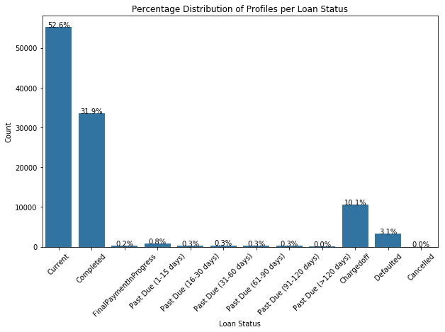

```python
#-- obtaining the count per loan status category in decreasing order of count
status_counts = loans_sub['loanstatus'].value_counts()
#-- obtaining the total number of status counts overall
n_status = status_counts.sum()
#-- obtaining the maximum status count
max_status_count = status_counts[0]
#-- calculating the proportions of loan status with respect to the overall population count
max_status_prop = max_status_count/n_status
status_props = np.arange(0,max_status_prop,0.05)
# plotting
plt.figure(figsize=(10,6))
sb.countplot('loanstatus',data=loans_sub,color=color)
locs,labels = plt.xticks(rotation=45)
for loc, label in zip(locs,labels):
    count = status_counts[label.get_text()]
    pct_string = '{:0.1f}%'.format(100*count/n_status)
    plt.text(loc,count+2,pct_string,ha='center',color='black')

plt.xlabel('Loan Status')
plt.ylabel('Count')
plt.title('Percentage Distribution of Profiles per Loan Status');
```

> **As can be seen, the distribution per loan status remains as it before the feature engineering and most of the loans are currenly ongoing.**

#### Listing Category

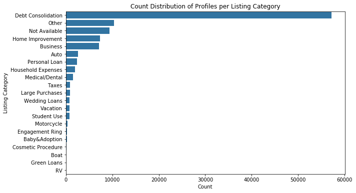

```python
#-- retrieving the index of listing categories in descending order of counts
index_category = loans_sub['listingcategory'].value_counts().index
# plotting
plt.figure(figsize=(10,6))
sb.countplot(y='listingcategory',data=loans_sub,color=color,order=index_category)
plt.ylabel('Listing Category')
plt.xlabel('Count')
plt.title('Count Distribution of Profiles per Listing Category');
```

> **Most people are taking out loans to settle their debts**

#### Occupation

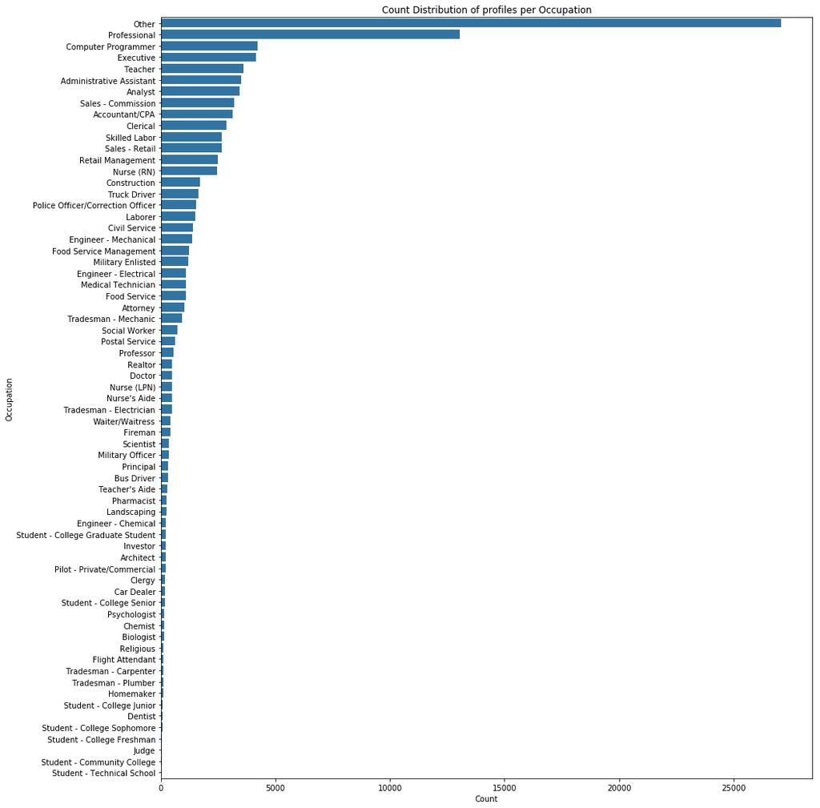

```python
#-- retrieving the index of occupation entries in descending order of counts
index_occupation = loans_sub['occupation'].value_counts().index
# plotting
plt.figure(figsize=(15,18))
sb.countplot(y='occupation',data=loans_sub,color=color,order=index_occupation)
plt.ylabel('Occupation')
plt.xlabel('Count')
plt.title('Count Distribution of profiles per Occupation');
```

> **We see that a lot of skilled workers take out loans compared with the likes of artisans, service men and clergy men.**

#### Employment Status

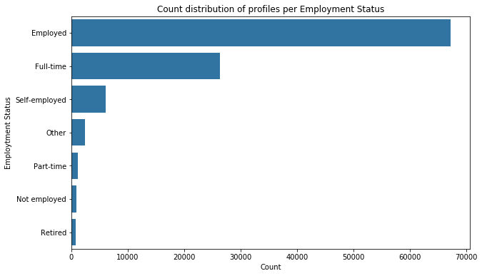

```python
#-- retrieving the index of Employment status entries in descending order of counts
index_employment = loans_sub['employmentstatus'].value_counts().index
#plotting
plt.figure(figsize=(10,6))
sb.countplot(y='employmentstatus',data=loans_sub,color=color,order=index_employment)
plt.ylabel('Employtment Status')
plt.xlabel('Count')
plt.title('Count distribution of profiles per Employment Status');
```

> **We see here that the majority of people who took out loans are in paid employment**

### Income Range

- Clearly, the income range is ordinal in nature and should be treated as such. Therefore, we convert it to ordinal.

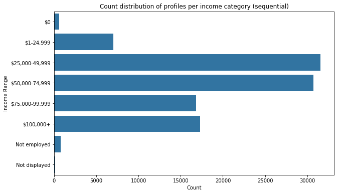

```python
#-- retrieving the pandas version to isolate the digit before the decimal
pd_ver = pd.__version__.split(".")

#-- income ranges in order of significance
income_classes = ['$0', '$1-24,999', '$25,000-49,999', '$50,000-74,999','$75,000-99,999',
                '$100,000+','Not employed','Not displayed']
if (int(pd_ver[0]) > 0) or (int(pd_ver[1]) >= 21): # v0.21 or later
    inc_classes = pd.api.types.CategoricalDtype(ordered = True, categories = income_classes)
    loans_sub['incomerange'] = loans_sub['incomerange'].astype(inc_classes)
else: # pre-v0.21
    loans_sub['incomerange'] = loans_sub['incomerange'].astype('category', ordered = True,categories = income_classes)
# plotting
plt.figure(figsize=(10,6))
sb.countplot(y='incomerange',data=loans_sub,color=color)
plt.ylabel('Income Range')
plt.xlabel('Count')
plt.title('Count distribution of profiles per income category (sequential)');
```

> **Most people who took out loans are mid-range income earners. Its quite funny also that some individuals who have no income have taken out loans**

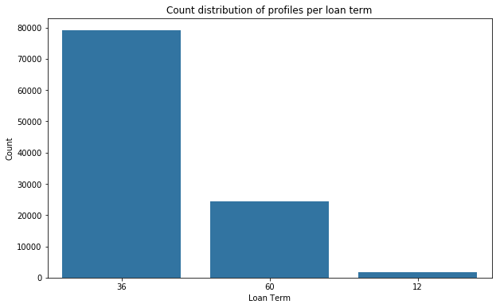

```python
#-- retrieving the index of loan term entries in descending order of counts
index_term = loans_sub.term.value_counts().index
# plotting
plt.figure(figsize=(10,6))
sb.countplot(x='term',data=loans_sub,color=color,order=index_term)
plt.xlabel('Loan Term')
plt.ylabel('Count')
plt.title('Count distribution of profiles per loan term');
```

> **Most borrowers seem to have preference for long-term loans**

### How are the continuous (numerical) variables distributed ?

#### We start by describing each of the continuous variables to inspect the range of values and specify bins

```python
loans_sub['borrowerapr'].describe()
```

```
count    104983.000000
mean          0.220311
std           0.081087
min           0.006530
25%           0.157130
50%           0.210510
75%           0.285740
max           0.423950
Name: borrowerapr, dtype: float64
```

```python
loans_sub['borrowerrate'].describe()
```

```
count    104983.000000
mean          0.193130
std           0.075359
min           0.000000
25%           0.133400
50%           0.184000
75%           0.251100
max           0.360000
Name: borrowerrate, dtype: float64
```

```python
loans_sub['lenderyield'].describe()
```

```
count    104983.000000
mean          0.183005
std           0.075127
min          -0.010000
25%           0.123400
50%           0.173000
75%           0.241100
max           0.340000
Name: lenderyield, dtype: float64
```

### We see that the three variables above share a rather similar bin interval. Therefore, to avoid code repitition, we write a function that automates the histogram plots for all three of them.

```python
def count_func(data,xVar):
    '''This function plots a histogram depicting the distribution of a continuous
    variable on the x-axis

    input: Dataframe, X-variable

    output: formatted histogram with title and defined bins'''

    # set plot dimensions
    plt.figure(figsize=(10,6))

    #set the bins for distribution
    bins = np.arange(0,data[str(xVar)].max()+0.01,0.01)

    # plot
    plt.hist(x=xVar,data=data,bins=bins)

    # add title to plot
    plt.title(f'''Distribution of {xVar}'''.title())

    # add x label
    plt.xlabel(xVar.title())

    # add y label
    plt.ylabel('Count'.title())
```

### Next, we call the function for all three variables and the dataframe

#### Borrower APR

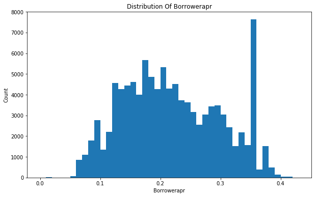

```python
count_func(loans_sub,'borrowerapr')
```

#### Borrower Rate

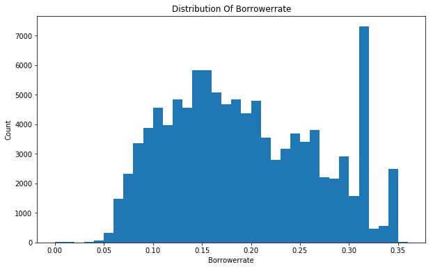

```python
count_func(loans_sub,'borrowerrate')
```

#### Lender Yield

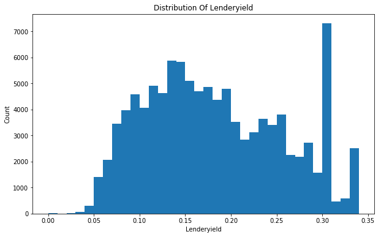

```python
count_func(loans_sub,'lenderyield')
```

> **We see a very similar distribution for Borrower rate, Borrower APR, and Lender yield. The three distributions peak between 0.30 and 0.35**

#### Employment Status Duration

```python
# inspecting the bin intervals for employment status duration
loans_sub['employmentstatusduration'].describe()
```

```
count    104983.000000
mean         96.212720
std          93.758734
min           0.000000
25%          26.000000
50%          67.000000
75%         137.000000
max         755.000000
Name: employmentstatusduration, dtype: float64
```

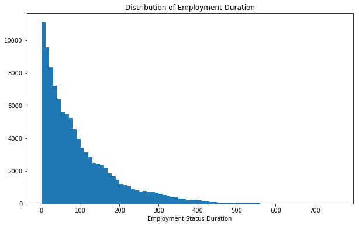

```python
# specifying bin size for the plot
bins = np.arange(0,loans_sub['employmentstatusduration'].max()+10,10)
#plotting
plt.figure(figsize=(10,6))
plt.hist(x='employmentstatusduration',data=loans_sub,bins=bins)
plt.xlabel('Employment Status Duration')
plt.title('Distribution of Employment Duration');
```

### Seeing that the above distribution is highly skewed to the right, there is need to transform the x-scale for normality

```python
# Transform the describe() of employment status duration to a scale of log10
log_emp = np.log10(loans_sub['employmentstatusduration'].describe())
```

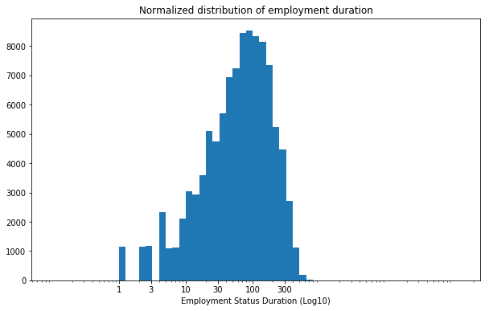

```python
# specifying the bin size for the plot
bins_emp = 10**np.arange(-1,log_emp.max()+0.1,0.1)

# generating the x-ticks
ticks = [1,3,10,30,100,300,]

# Convert ticks into string values, to be displaye dlong the x-axis
name = ['{}'.format(v) for v in ticks]

# plotting the histogram
plt.figure(figsize=(10,6))
plt.hist(x='employmentstatusduration',data=loans_sub,bins=bins_emp)
plt.xlabel('Employment Status Duration (Log10)');
plt.xscale('log')
plt.xticks(ticks,name)
plt.title('Normalized distribution of employment duration');
```

> **Having normalized the x-scale, we see that the distribution is more normal and unimodal with most borrowers having been employed for between 80-90 months**

#### Available Bank CardCredit

```python
# inspecting the bin intervals for available bank card credit
loans_sub['availablebankcardcredit'].describe()
```

```
count    104983.000000
mean      11227.672061
std       19836.343797
min           0.000000
25%         879.000000
50%        4110.000000
75%       13226.000000
max      646285.000000
Name: availablebankcardcredit, dtype: float64
```

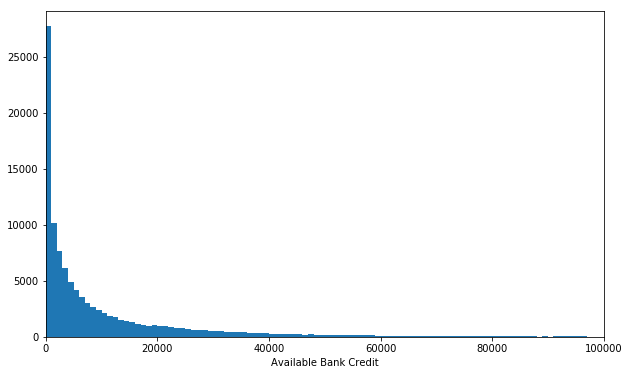

```python
# specifying the bin size for the plot
bins = np.arange(0,loans_sub['availablebankcardcredit'].max()+1000,1000)
# plotting
plt.figure(figsize=(10,6))
plt.hist(x='availablebankcardcredit',data=loans_sub,bins=bins)
plt.xlabel('Available Bank Credit')
plt.xlim(0,100000);
```

### The above distribution is highly skewed, therefore we move to transform the x-axis

```python
# Transform the describe() of available bank card credit to a scale of log10
log_bank = np.log10(loans_sub['availablebankcardcredit'].describe())
```

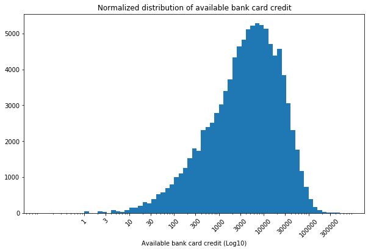

```python
# specifying the bin size for the plot
bins_bank = 10**np.arange(-1,log_bank.max()+0.1,0.1)

# generating the x-ticks
ticks = [1,3,10,30,100,300,1000,3000,10000,30000,100000,300000]

# Convert ticks into string values, to be displaye dlong the x-axis
name = ['{}'.format(v) for v in ticks]

# plotting the histogram
plt.figure(figsize=(10,6))
plt.hist(x='availablebankcardcredit',data=loans_sub,bins=bins_bank)
plt.xlabel('Available bank card credit (Log10)');
plt.xscale('log')
plt.xticks(ticks,name,rotation=45)
plt.title('Normalized distribution of available bank card credit');
```

> **The distribution is now unimodal and peaks somewhere between 3,000 USD and 10,000 USD. This represents the majority bank card credit for borrowers**

#### Monthly Payment

```python
# inspecting the bin intervals for monthly loan payment
loans_sub['monthlyloanpayment'].describe()
```

```
count    104983.000000
mean        279.290395
std         192.505132
min           0.000000
25%         138.760000
50%         229.470000
75%         377.980000
max        2251.510000
Name: monthlyloanpayment, dtype: float64
```

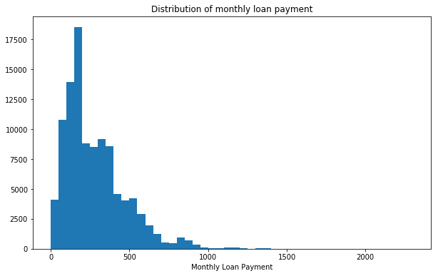

```python
# specifying the bin size for the plot
bins = np.arange(0,loans_sub['monthlyloanpayment'].max()+50,50)

# plotting the histogram
plt.figure(figsize=(10,6))
plt.hist(x='monthlyloanpayment',data=loans_sub,bins=bins)
plt.xlabel('Monthly Loan Payment')
plt.title('Distribution of monthly loan payment');
```

### Seeing that the above distribution is skewed, we also transform the x-scale for normality.

```python
# Transform the describe() of monthly loan payment to a scale of log10
log_pay = np.log10(loans_sub['monthlyloanpayment'].describe())
```

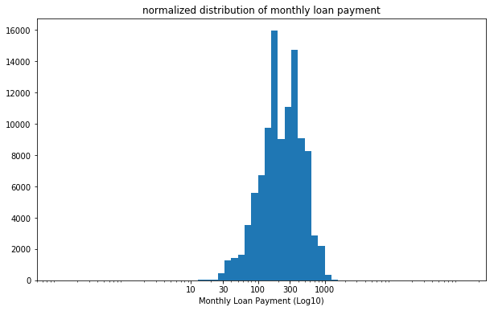

```python
# specifying the bin size for the plot
bins_pay = 10**np.arange(-1,log_pay.max()+0.1,0.1)

# generating the x-ticks
ticks = [10,30,100,300,1000]

# Convert ticks into string values, to be displaye dlong the x-axis
name = ['{}'.format(v) for v in ticks]

# plotting the histogram
plt.figure(figsize=(10,6))
plt.hist(x='monthlyloanpayment',data=loans_sub,bins=bins_pay)
plt.xlabel('Monthly Loan Payment (Log10)');
plt.xscale('log')
plt.xticks(ticks,name)
plt.title('normalized distribution of monthly loan payment');
```

> **Having transformed the x-scale, we can now see clearly that most repayments are around 200 USD and very few repayments exceed 1000 USD**

### Discuss the distribution(s) of your variable(s) of interest. Were there any unusual points? Did you need to perform any transformations?

> Most loans are currently ongoing with the borrower being mostly skilled professionals in paid employment. We see a bit of engagement also from people without an income, which is quite interesting. The employment duration and monthly payment distributions were rather awkward compared with the borrower rate, borrower APR and lender yield.

### Of the features you investigated, were there any unusual distributions? Did you perform any operations on the data to tidy, adjust, or change the form of the data? If so, why did you do this?

> The monthly payment and employment duration distributions were highly skewed and needed scale transformation to confer normality. A logarithmic transformation was carried out in both cases for the axis bearing the bins.

## Bivariate Exploration

> In this section, investigate relationships between pairs of variables in your data. Make sure the variables that you cover here have been introduced in some fashion in the previous section (univariate exploration).

### It seemed before like the borrower APR, borrower rate and lender yield all have identical distributions. We start bivariate exploration by further investigating relationship using a scatter plot.

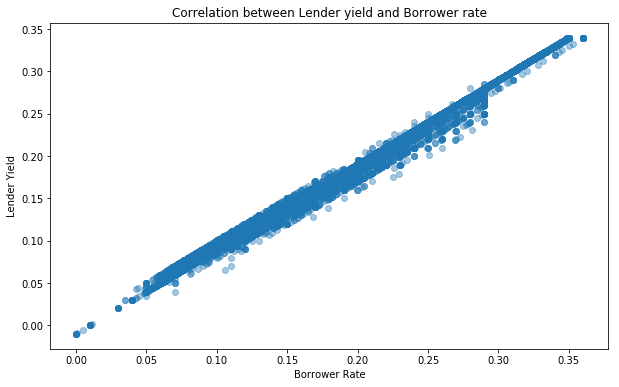

```python
#-- making a regression plot of lender yield against borrower rate
plt.figure(figsize=(10,6))
sb.regplot('borrowerrate','lenderyield',data=loans_sub,fit_reg=False,scatter_kws={'alpha':0.4})
plt.xlabel('Borrower Rate')
plt.ylabel('Lender Yield')
plt.title('Correlation between Lender yield and Borrower rate');
```

[figure not shown]

```python
#-- making a regression plot of borrower rate against borrower APR
plt.figure(figsize=(10,6))
sb.regplot('borrowerrate','borrowerapr',data=loans_sub,fit_reg=False,scatter_kws={'alpha':0.4})
plt.xlabel('Borrower Rate')
plt.ylabel('Borrower APR')
plt.title('Correlation between Lender yield and Borrower Rate');
```

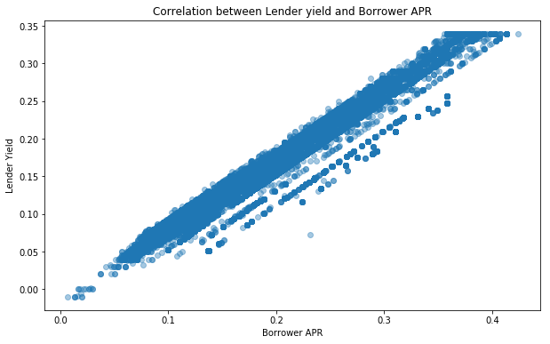

```python
#-- making a regression plot of lender yield against borrower APR
plt.figure(figsize=(10,6))
sb.regplot('borrowerapr','lenderyield',data=loans_sub,fit_reg=False,scatter_kws={'alpha':0.4})
plt.xlabel('Borrower APR')
plt.ylabel('Lender Yield')
plt.title('Correlation between Lender yield and Borrower APR');
```

> **We now confirm that all three variables represented in the scatter plots above are strongly correlated. The lender yield and borrower rate going by the histograms and scatter plots are equal in context. The yield is percentage of earnings a lender earns for lending money which translates to the eventual interest levied on the borrower. This explains the strong linear relationship between both variables. The APR differs a bit because it includes other charges representing the cost of the loan to the borrower. This explains slight deviations from the line of best fit on the scatter plots and xbins difference in the histograms.**

### Plot the continuous variables against the target variable (Loan Status)

#### Loan status vs Lender Yield

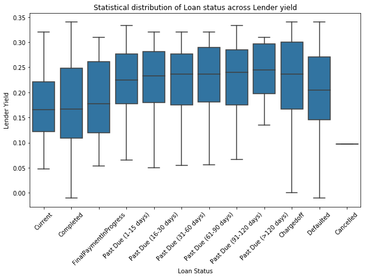

```python
#-- making a boxplot of lender yield against loan status
plt.figure(figsize=(10,6))
sb.boxplot('loanstatus','lenderyield',data=loans_sub,color=color)
plt.xlabel('Loan Status')
plt.ylabel('Lender Yield')
plt.xticks(rotation=45)
plt.title('Statistical distribution of Loan status across Lender yield');
```

#### Loan Status vs Borrower Rate

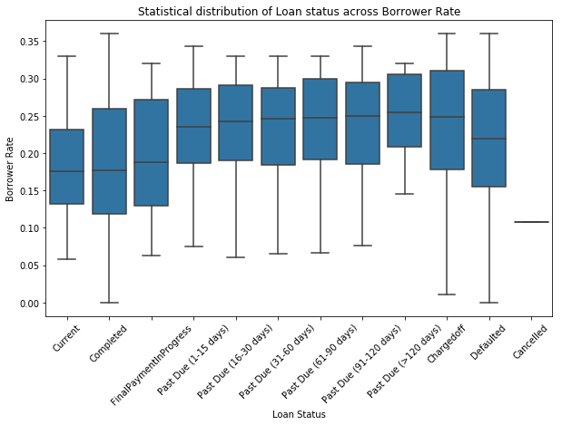

```python
#-- making a boxplot of borrower rate against loan status
plt.figure(figsize=(10,6))
sb.boxplot('loanstatus','borrowerrate',data=loans_sub,color=color)
plt.xlabel('Loan Status')
plt.ylabel('Borrower Rate')
plt.xticks(rotation=45)
plt.title('Statistical distribution of Loan status across Borrower Rate');
```

> **The above box plot further confirms the strong postive correlation between lender yield and borrower rate. Again, the lower boundary is favored.**

#### Loan Status vs Borrower APR

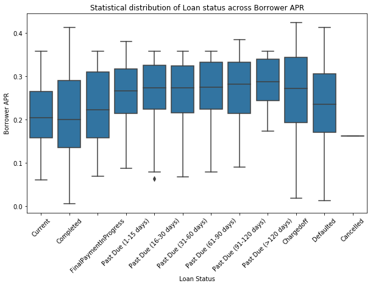

```python
#-- making a boxplot of borrower APR against loan status
plt.figure(figsize=(10,6))
sb.boxplot('loanstatus','borrowerapr',data=loans_sub,color=color)
plt.xlabel('Loan Status')
plt.ylabel('Borrower APR')
plt.xticks(rotation=45)
plt.title('Statistical distribution of Loan status across Borrower APR');
```

> **Here, we see a very similar trend to what was seen for lender yield. And naturally, since lower lender yields mean lower borrower rates and APR, completed loans fell to the lower boundary of the average APR**

#### Loan Status vs Monthly Loan Payment

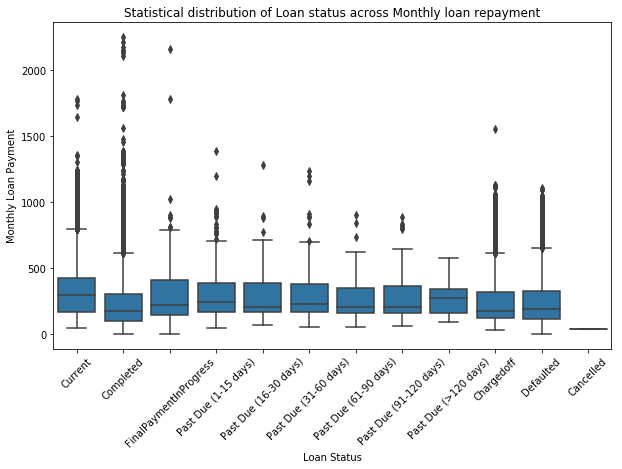

```python
#-- making a boxplot of monthly loan payment against loan status
plt.figure(figsize=(10,6))
sb.boxplot('loanstatus','monthlyloanpayment',data=loans_sub,color=color)
plt.xlabel('Loan Status')
plt.ylabel('Monthly Loan Payment')
plt.xticks(rotation=45)
plt.title('Statistical distribution of Loan status across Monthly loan repayment');
```

> **We have seen that completed loans generally has lower interest rates and loans fees. Therefore, the average resulting monthly payment is lower than other categories as can be seen in the box plot above.**

#### Loan Status vs Employment Duration

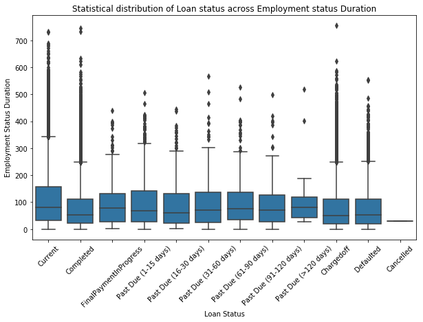

```python
#-- making a boxplot of employment status duration against loan status
plt.figure(figsize=(10,6))
sb.boxplot('loanstatus','employmentstatusduration',data=loans_sub,color=color)
plt.xlabel('Loan Status')
plt.ylabel('Employment Status Duration')
plt.xticks(rotation=45)
plt.title('Statistical distribution of Loan status across Employment status Duration');
```

#### Loan Status vs Available Bank Card Credit

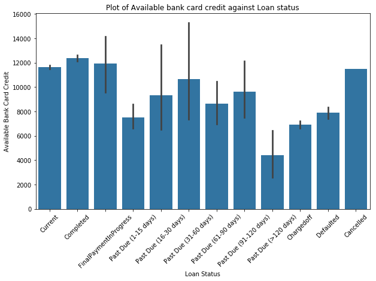

```python
#-- making a barplot of available bank card credit against loan status
plt.figure(figsize=(10,6))
sb.barplot('loanstatus','availablebankcardcredit',data=loans_sub,color=color)
plt.xlabel('Loan Status')
plt.ylabel('Available Bank Card Credit')
plt.xticks(rotation=45)
plt.title('Plot of Available bank card credit against Loan status');
```

> **People who have completed their loans have quite high available bank card credit. It wouldn't be so off to assume that they are high networth or high-earning individuals or maybe they offset the debt from their bank cards.**

#### Loan Status vs Loan Term

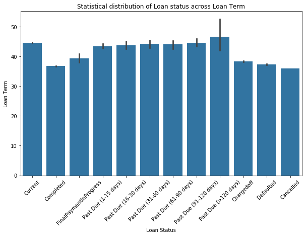

```python
#-- making a barplot of loan term against loan status
plt.figure(figsize=(10,6))
sb.barplot('loanstatus','term',data=loans_sub,color=color)
plt.xlabel('Loan Status')
plt.ylabel('Loan Term')
plt.xticks(rotation=45)
plt.title('Statistical distribution of Loan status across Loan Term');
```

> **Completed loans witness shorter loan terms which could mean that they are smaller in value compared with other larger loans which take time to pay back or are difficult to keep up with altogether.**

### Plots of Loan status distribution across Income Ranges and Employment Status

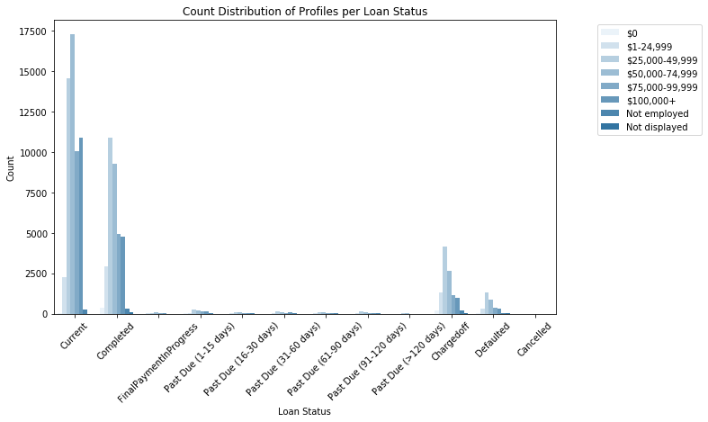

```python
# making a barplot showing interaction between loan status and income range by decreasing order of count
plt.figure(figsize=(10,6))
sb.countplot('loanstatus',data=loans_sub,color=color,hue='incomerange')
plt.xticks(rotation=45)
plt.xlabel('Loan Status')
plt.ylabel('Count')
plt.title('Count Distribution of Profiles per Loan Status')
# positioining the legend outside of the plot area
plt.legend(loc='upper right', bbox_to_anchor=(1.3, 1.0));
```

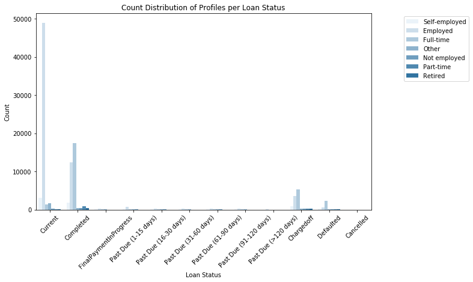

```python
# making a barplot showing interaction between loan status and employment status by decreasing order of count
plt.figure(figsize=(10,6))
sb.countplot('loanstatus',data=loans_sub,hue='employmentstatus',color=color)
plt.xticks(rotation=45)
plt.xlabel('Loan Status')
plt.ylabel('Count')
plt.title('Count Distribution of Profiles per Loan Status')
# positioining the legend outside of the plot area
plt.legend(loc='upper right', bbox_to_anchor=(1.3, 1.0));
```

> **People who are employed tend to borrow more and the count of borrowers in these categories, increases with increasing income up until the mid-range earners. As one would expect, from this point, it starts to drop off and we see fewer borrowers in the higher-earning categories.**

### Comparing the categorical variables

#### Loan Status and Income Range

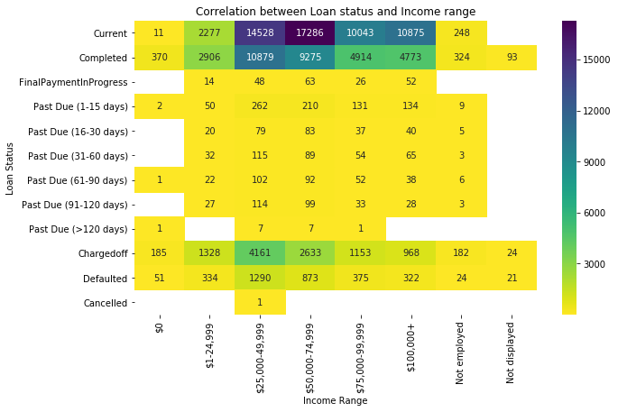

```python
# Use group_by() and size() to get the number of cars and each combination of the two variable levels as a pandas Series
ls_counts = loans_sub.groupby(['loanstatus', 'incomerange']).size()
# Use Series.reset_index() to convert a series into a dataframe object
ls_counts = ls_counts.reset_index(name='count')
# Use DataFrame.pivot() to rearrange the data, to have vehicle class on rows
ls_counts = ls_counts.pivot(index = 'loanstatus', columns = 'incomerange', values = 'count')
# plotting
plt.figure(figsize=(10,6))
sb.heatmap(ls_counts,annot = True, fmt = '.0f',cmap='viridis_r')
plt.xlabel('Income Range')
plt.ylabel('Loan Status')
plt.title('Correlation between Loan status and Income range');
```

> **The heatmap above somehow, confirms the previously observed trend for income ranges. We see an increase in number of current loans across the heatmap from left to right and a drop off after the 75,000 USD mark. The trend is similar for completed loans up until the 50,000 USD mark after which there is a drop off**

#### Loan Status and Employment Status

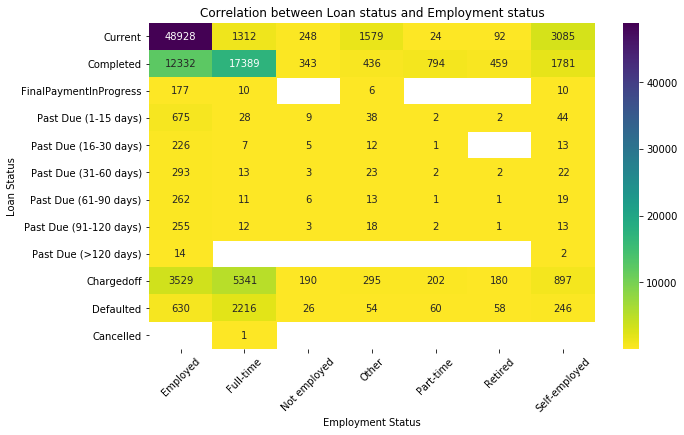

```python
# Use group_by() and size() to get the number of cars and each combination of the two variable levels as a pandas Series
es_counts = loans_sub.groupby(['loanstatus', 'employmentstatus']).size()
# Use Series.reset_index() to convert a series into a dataframe object
es_counts = es_counts.reset_index(name='count')
# Use DataFrame.pivot() to rearrange the data, to have vehicle class on rows
es_counts = es_counts.pivot(index = 'loanstatus', columns = 'employmentstatus', values = 'count')
# plotting
plt.figure(figsize=(10,6))
sb.heatmap(es_counts,annot = True, fmt = '.0f',cmap='viridis_r')
plt.xlabel('Employment Status')
plt.ylabel('Loan Status')
plt.title('Correlation between Loan status and Employment status')
plt.xticks(rotation=45);
```

> **The heatmap confirms that employed individuals interact the most with loans given the color indication and count of profiles in the Employed and Full-time categories for current and completed loans.**

#### Loan Status and Listing Category

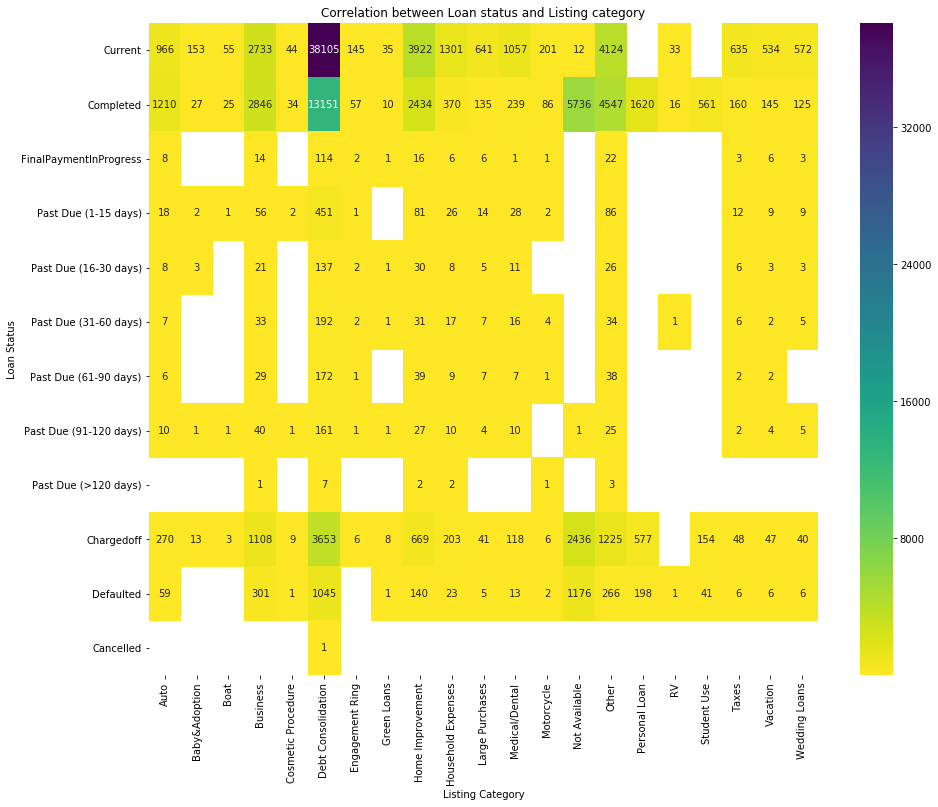

```python
# Use group_by() and size() to get the number of cars and each combination of the two variable levels as a pandas Series
lc_counts = loans_sub.groupby(['loanstatus', 'listingcategory']).size()
# Use Series.reset_index() to convert a series into a dataframe object
lc_counts = lc_counts.reset_index(name='count')
# Use DataFrame.pivot() to rearrange the data, to have vehicle class on rows
lc_counts = lc_counts.pivot(index = 'loanstatus', columns = 'listingcategory', values = 'count')
# plotting
plt.figure(figsize=(15,12))
sb.heatmap(lc_counts,annot = True, fmt = '.0f',cmap='viridis_r')
plt.xlabel('Listing Category')
plt.ylabel('Loan Status')
plt.title('Correlation between Loan status and Listing category');
```

> **The above heatmap reveals the most interesting fact throughout this analysis. Most people borrow loans to pay off other loans. Other key reasons include: business and home improvement.**

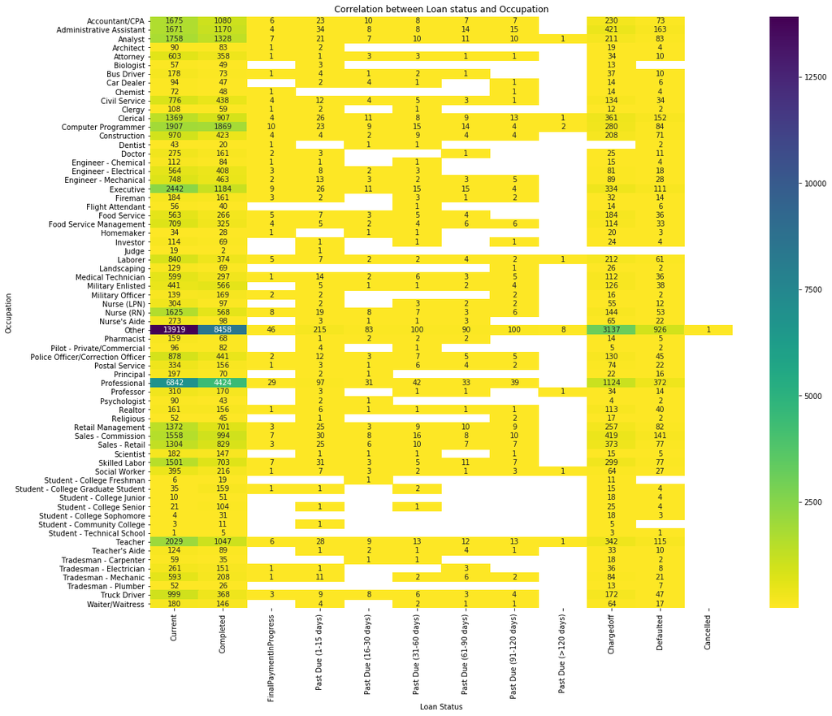

```python
# Use group_by() and size() to get the number of cars and each combination of the two variable levels as a pandas Series
oc_counts = loans_sub.groupby(['loanstatus', 'occupation']).size()
# Use Series.reset_index() to convert a series into a dataframe object
oc_counts = oc_counts.reset_index(name='count')
# Use DataFrame.pivot() to rearrange the data, to have vehicle class on rows
oc_counts = oc_counts.pivot(index = 'occupation', columns = 'loanstatus', values = 'count')
# plotting
plt.figure(figsize=(18,15))
sb.heatmap(oc_counts,annot = True, fmt = '.0f',cmap='viridis_r')
plt.xlabel('Loan Status')
plt.ylabel('Occupation')
plt.title('Correlation between Loan status and Occupation');
```

> **We see a further confirmation that professionals who are supposedly earning decent sums interact with loans more than artisans and unskilled workers.**

### Did you observe any interesting relationships between the other features (not the main feature(s) of interest)?

> The relationship between listing category stood out for revealing that most people borrow to pay off other debts.